# MSCA_HW5_Moushumi

Moushumi Pardesi

2023-04-29

```r
library(readxl)
library(forecast)
library(xts)
library(dplyr)
library(AICcmodavg)
library(lubridate)
library(tidyverse)
library(fracdiff)
library(tseries)
library(lmtest)
library(lmtest)
library(forecast)
library(MASS)
library(bbotk)
library(rms)
library(boot)
setwd("/Users/moush/Desktop/UChicago FINM/Time Series")
Gasfurn<-data.frame(read.csv("Gas Furnace Dataset.csv"))
Gasfurn<-Gasfurn%>%rename(independent=Input.gas.rate, dependent=Outlet.gas.CO2.percentage)
```

## Task1

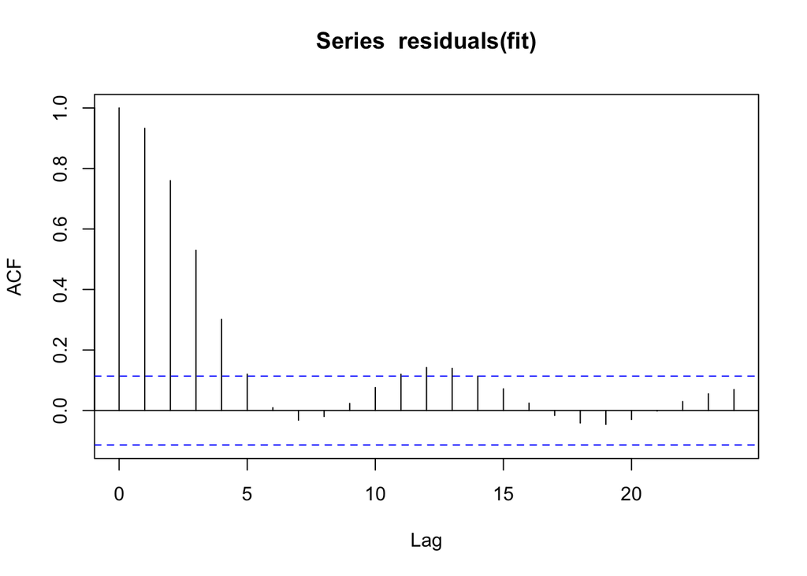

```r
fit <- lm(Gasfurn$dependent ~ Gasfurn$independent, data = Gasfurn)

acf(residuals(fit))
```

Ans1 - It appears that there is significant correlation in the residuals upto the 4th lag. This violates of the assumption of independence in the linear regression model.

## Task2

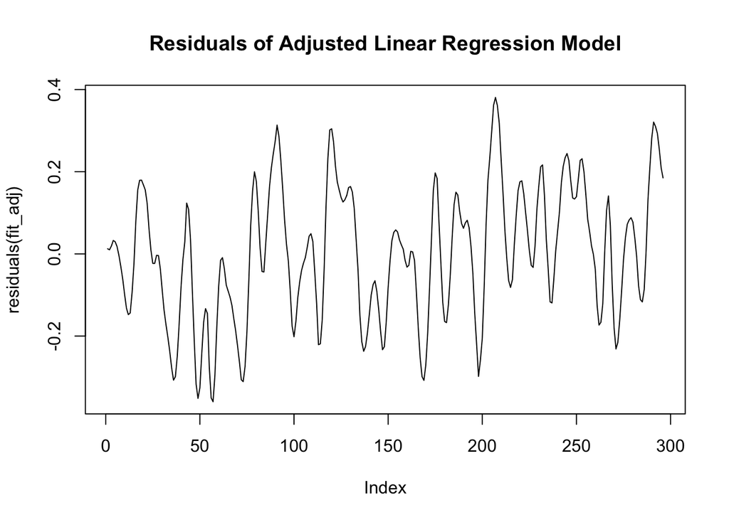

```r
resid<-residuals(fit)

arima_resid <- arima(resid, order = c(0, 0, 1))

adj_gas <- Gasfurn$dependent- arima_resid$coef[1] * resid

fit_adj <- lm(adj_gas ~ Gasfurn$independent, data = Gasfurn)


plot(residuals(fit_adj), type = "l", main = "Residuals of Adjusted Linear Regression Model")
```

## Task3

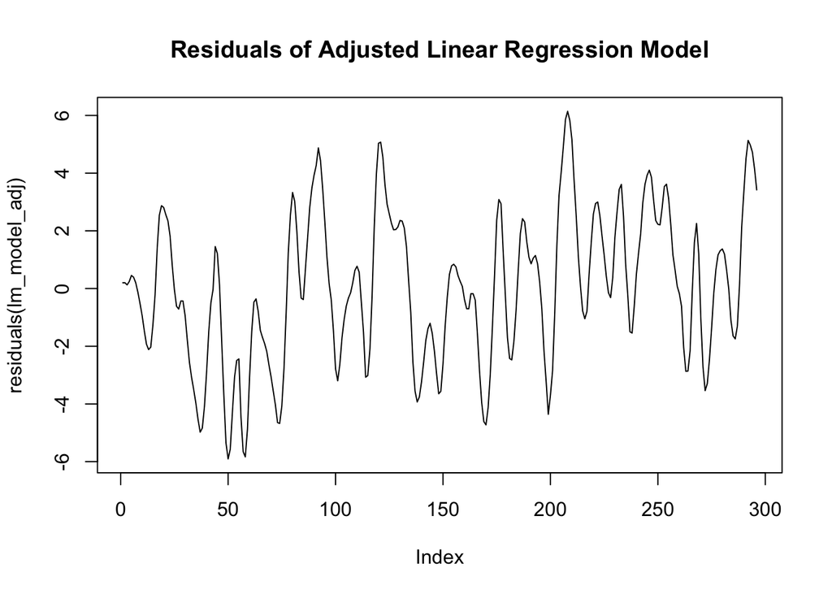

```r
arima_resid2 <- arima(resid, order = c(1, 0, 0))

dependent_adj <- resid - arima_resid2$residuals

lm_model_adj <- lm(dependent_adj ~ Gasfurn$independent)

plot(residuals(lm_model_adj), type = "l", main = "Residuals of Adjusted Linear Regression Model")
```

Ans3 - This plot resembles the plot with ARIMA(0,0,1) linear regression model adjusted with MA coefficient.

## Task4

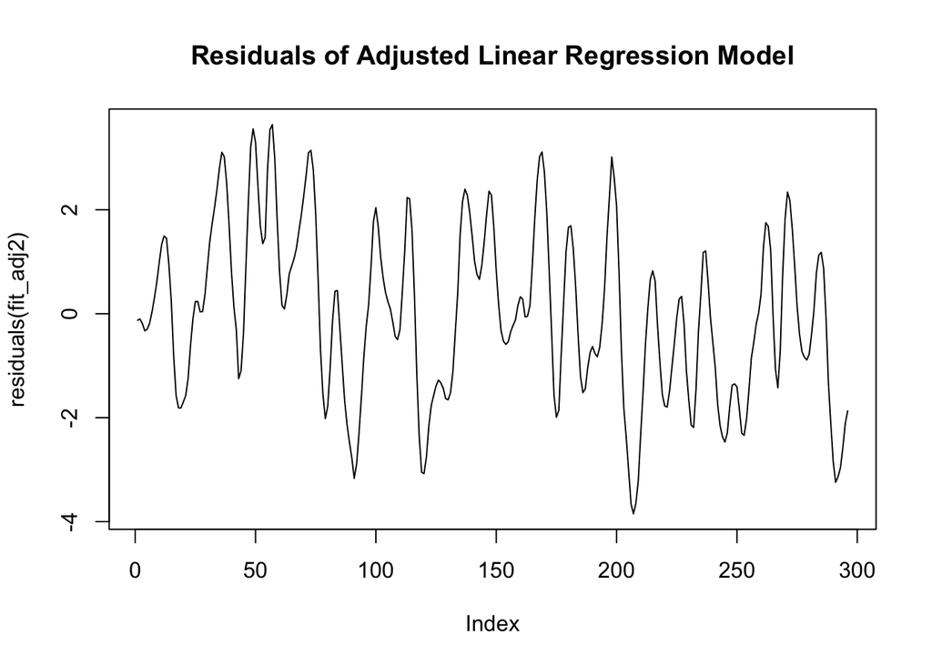

```r
arima_resid3 <- arima(resid, order = c(0, 0, 2))

adj_gas2 <- Gasfurn$dependent- arima_resid3$coef[1] * resid

fit_adj2 <- lm(adj_gas2 ~ Gasfurn$independent, data = Gasfurn)


plot(residuals(fit_adj2), type = "l", main = "Residuals of Adjusted Linear Regression Model")
```

## Task5

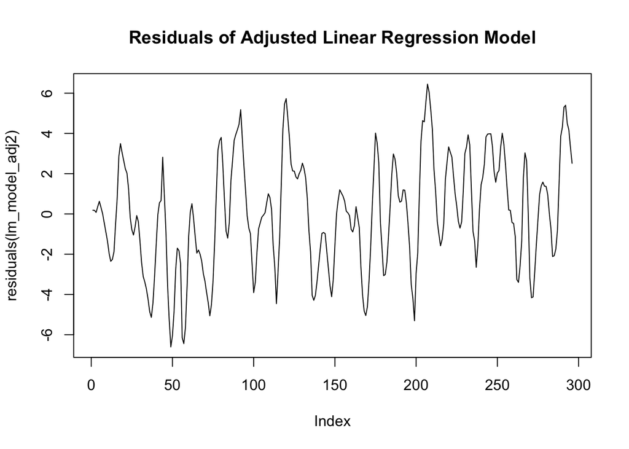

```r
arima_resid4 <- arima(resid, order = c(2, 0, 0))

dependent_adj <- resid - arima_resid4$residuals

lm_model_adj2 <- lm(dependent_adj ~ Gasfurn$independent)

plot(residuals(lm_model_adj2), type = "l", main = "Residuals of Adjusted Linear Regression Model")
```

## Task6

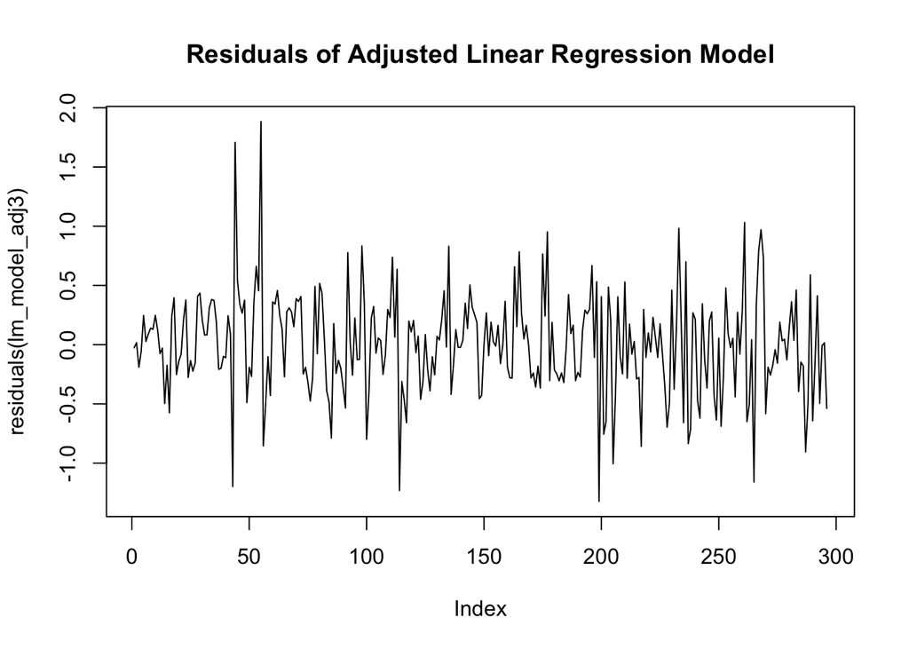

```r
arima_resid5 <- arima(resid, order = c(2,0,2))

dependent_adj1 <- resid - arima_resid5$residuals

independent_adj1 <- resid/arima_resid5$arma[5]

lm_model_adj3 <- lm(dependent_adj1 ~ independent_adj1)


plot(residuals(lm_model_adj3), type = "l", main = "Residuals of Adjusted Linear Regression Model")
```

## Task7

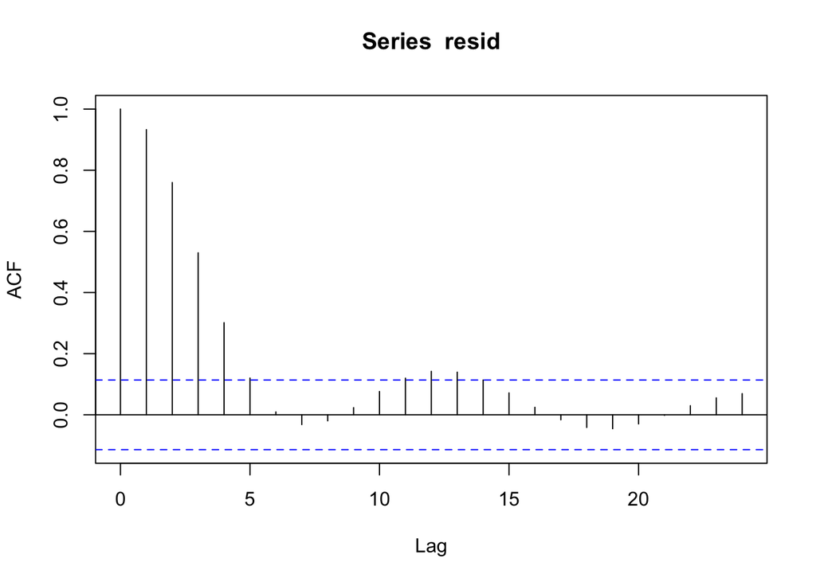

```r
acf(resid)
```

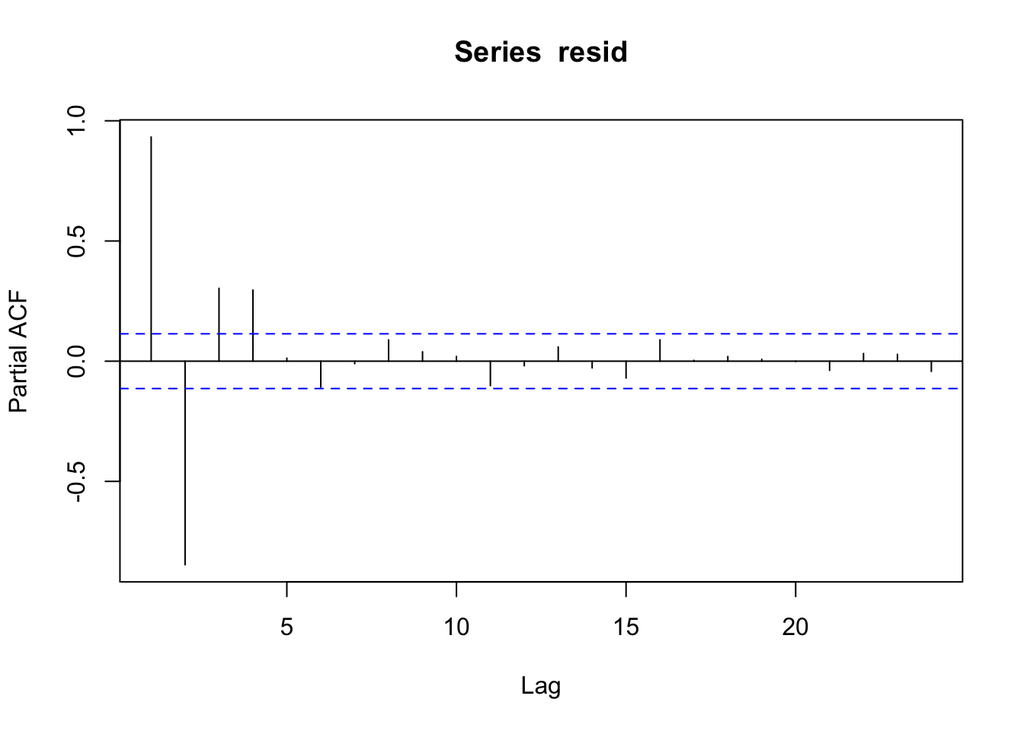

```r
pacf(resid)
```

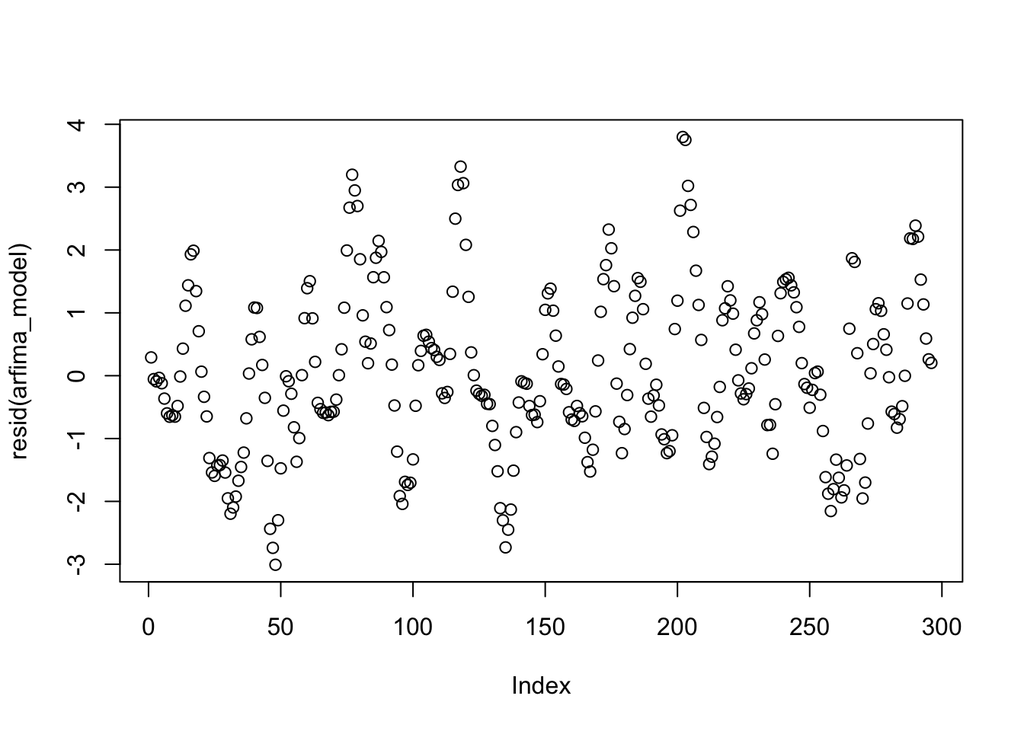

```r
arfima_model <- fracdiff::fracdiff(Gasfurn$dependent)

plot(resid(arfima_model))
```

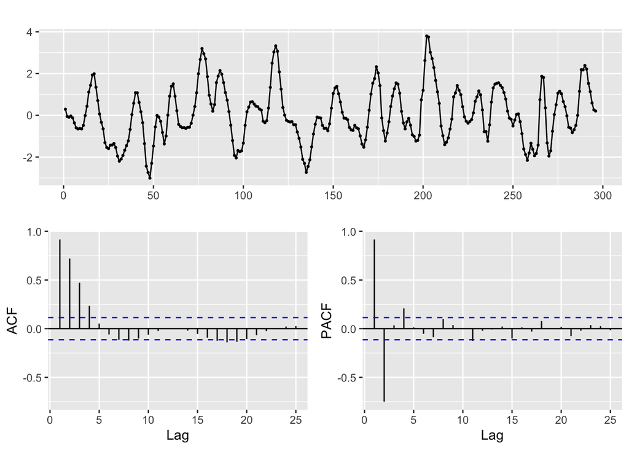

```r
ggtsdisplay(resid(arfima_model))
```

## Task8

```r
# Durbin-Watson tests
dwtest1 = sum((arima_resid$residuals - stats::lag(arima_resid$residuals))^2, na.rm = TRUE) /
       sum(arima_resid$residuals^2, na.rm = TRUE)
dwtest2 = sum((arima_resid2$residuals - stats::lag(arima_resid2$residuals))^2, na.rm = TRUE) /
       sum(arima_resid2$residuals^2, na.rm = TRUE)
dwtest3 = sum((arima_resid3$residuals - stats::lag(arima_resid3$residuals))^2, na.rm = TRUE) /
       sum(arima_resid3$residuals^2, na.rm = TRUE)
dwtest4 = sum((arima_resid4$residuals - stats::lag(arima_resid4$residuals))^2, na.rm = TRUE) /
       sum(arima_resid4$residuals^2, na.rm = TRUE)
dwtest5 = sum((arima_resid5$residuals - stats::lag(arima_resid5$residuals))^2, na.rm = TRUE) /
       sum(arima_resid5$residuals^2, na.rm = TRUE)
dwtest6 = sum((arfima_model$resid - stats::lag(arfima_model$resid))^2, na.rm = TRUE) /
       sum(arfima_model$resid^2, na.rm = TRUE)


# Box-Ljung tests
Box.test(arima_resid$residuals, lag = 20, type = "Ljung-Box")
```

```
##
##  Box-Ljung test
##
## data:  arima_resid$residuals
## X-squared = 495.66, df = 20, p-value < 2.2e-16
```

```r
Box.test(arima_resid2$residuals, lag = 20, type = "Ljung-Box")
```

```
##
##  Box-Ljung test
##
## data:  arima_resid2$residuals
## X-squared = 563.52, df = 20, p-value < 2.2e-16
```

```r
Box.test(arima_resid3$residuals, lag = 20, type = "Ljung-Box")
```

```
##
##  Box-Ljung test
##
## data:  arima_resid3$residuals
## X-squared = 355.83, df = 20, p-value < 2.2e-16
```

```r
Box.test(arima_resid4$residuals, lag = 20, type = "Ljung-Box")
```

```
##
##  Box-Ljung test
##
## data:  arima_resid4$residuals
## X-squared = 134.53, df = 20, p-value < 2.2e-16
```

```r
Box.test(arima_resid5$residuals, lag = 20, type = "Ljung-Box")
```

```
##
##  Box-Ljung test
##
## data:  arima_resid5$residuals
## X-squared = 33.762, df = 20, p-value = 0.02778
```

```r
Box.test(arfima_model$resid, lag = 20, type = "Ljung-Box")
```

```
##
##  Box-Ljung test
##
## data:  arfima_model$resid
## X-squared = 530.45, df = 20, p-value < 2.2e-16
```

```r
Models = c("ARIMA(0,0,1)", "ARIMA(1,0,0)", "ARIMA(0,0,2)", "ARIMA(2,0,0)", "ARIMA(2,0,2)", "ARFIMA")

AIC = c(arima_resid$aic, arima_resid2$aic, arima_resid3$aic, arima_resid4$aic, arima_resid5$aic, AIC(arfima_model))

BIC = c(BIC(arima_resid), BIC(arima_resid2), BIC(arima_resid3), BIC(arima_resid4), BIC(arima_resid5), BIC(arfima_model))

PvalueBoxLjung = c(Box.test(arima_resid$residuals, lag = 20, type = "Ljung-Box")$p.value, Box.test(arima_resid2$residuals, lag = 20, type = "Ljung-Box")$p.value, Box.test(arima_resid3$residuals, lag = 20, type = "Ljung-Box")$p.value, Box.test(arima_resid4$residuals, lag = 20, type = "Ljung-Box")$p.value, Box.test(arima_resid5$residuals, lag = 20, type = "Ljung-Box")$p.value, 0)

DurbinWatson  = c(dwtest1, dwtest2, dwtest3, dwtest4, dwtest5, dwtest6)

results_table<-data.frame(Models, AIC, BIC, PvalueBoxLjung, DurbinWatson)

results_table
```

```
##         Models       AIC       BIC PvalueBoxLjung DurbinWatson
## 1 ARIMA(0,0,1) 1090.5417 1101.6128     0.00000000    0.3346218
## 2 ARIMA(1,0,0)  844.2931  855.3642     0.00000000    0.3757153
## 3 ARIMA(0,0,2)  802.4343  817.1958     0.00000000    0.7196169
## 4 ARIMA(2,0,0)  432.7265  447.4879     0.00000000    1.1751648
## 5 ARIMA(2,0,2)  362.3761  384.5182     0.02778291    1.8569746
## 6       ARFIMA  999.1851 1006.5658     0.00000000    0.0000000
```

Ans8 - The above displays table for summaries of Durbin-Watson and Box-Ljung tests for each model to compare AICs, BICs and p-vaules for each test across the ARIMA and ARFIMA models

## Task9

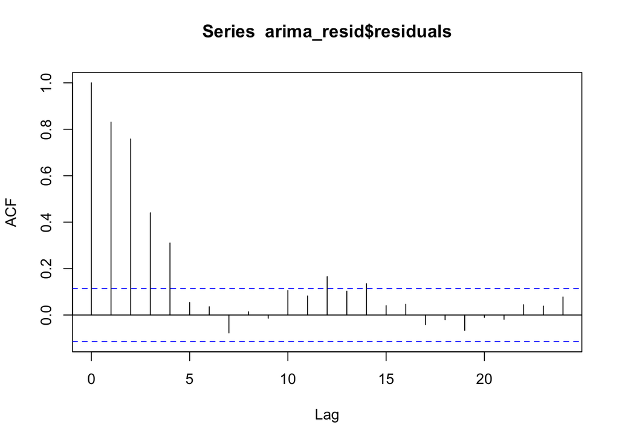

```r
acf(arima_resid$residuals)
```

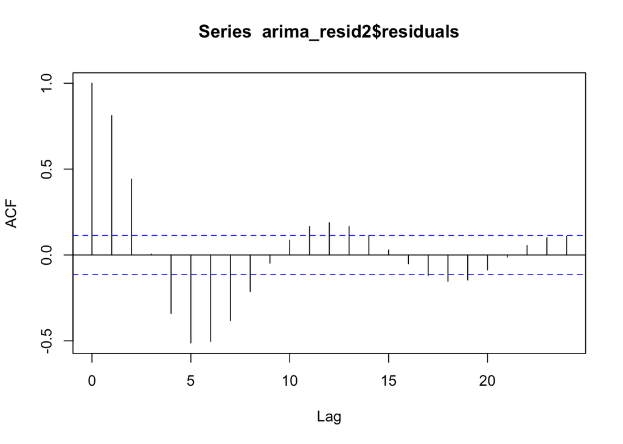

```r
acf(arima_resid2$residuals)
```

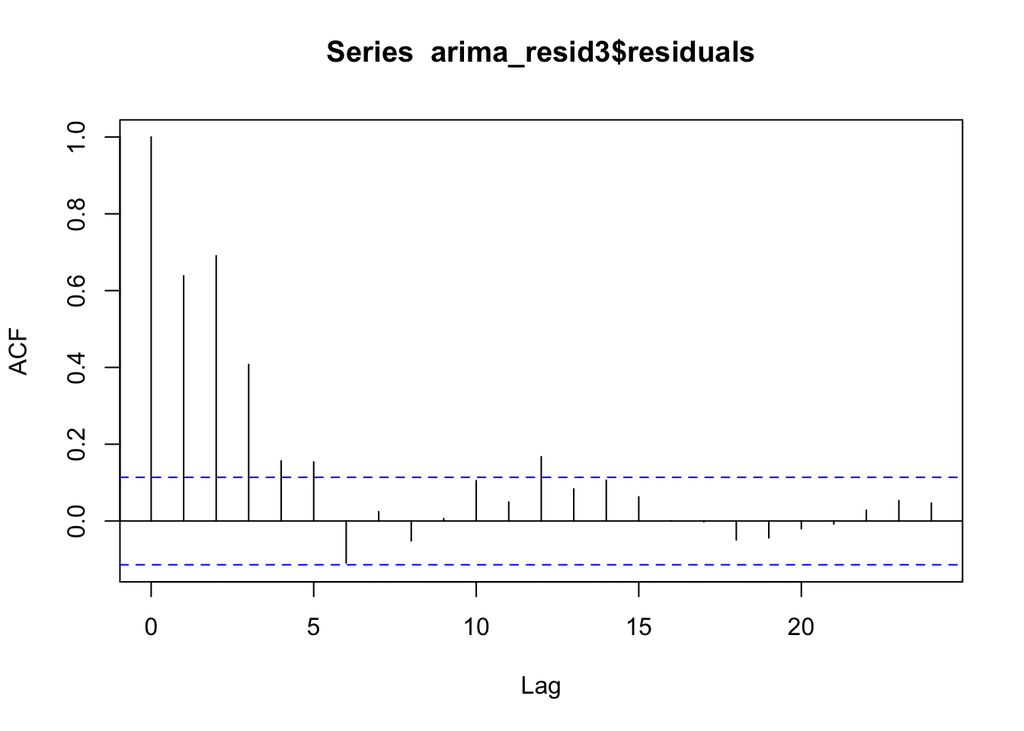

```r
acf(arima_resid3$residuals)
```

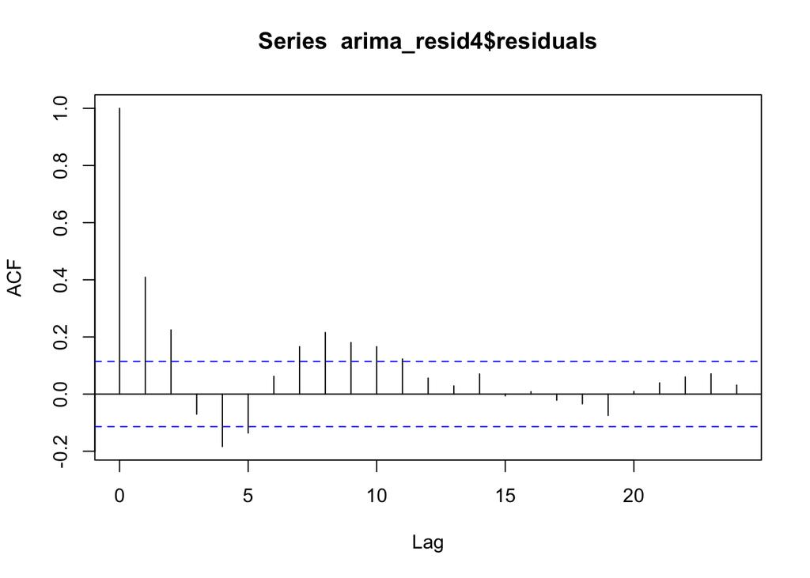

```r
acf(arima_resid4$residuals)
```

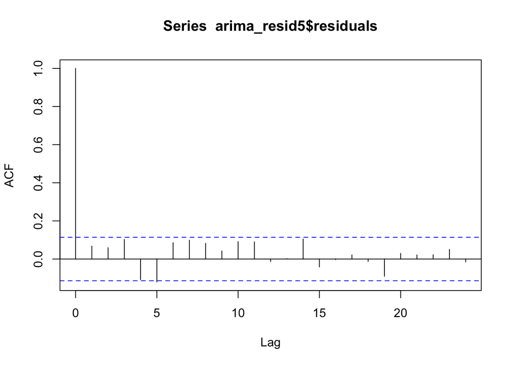

```r
acf(arima_resid5$residuals)
```

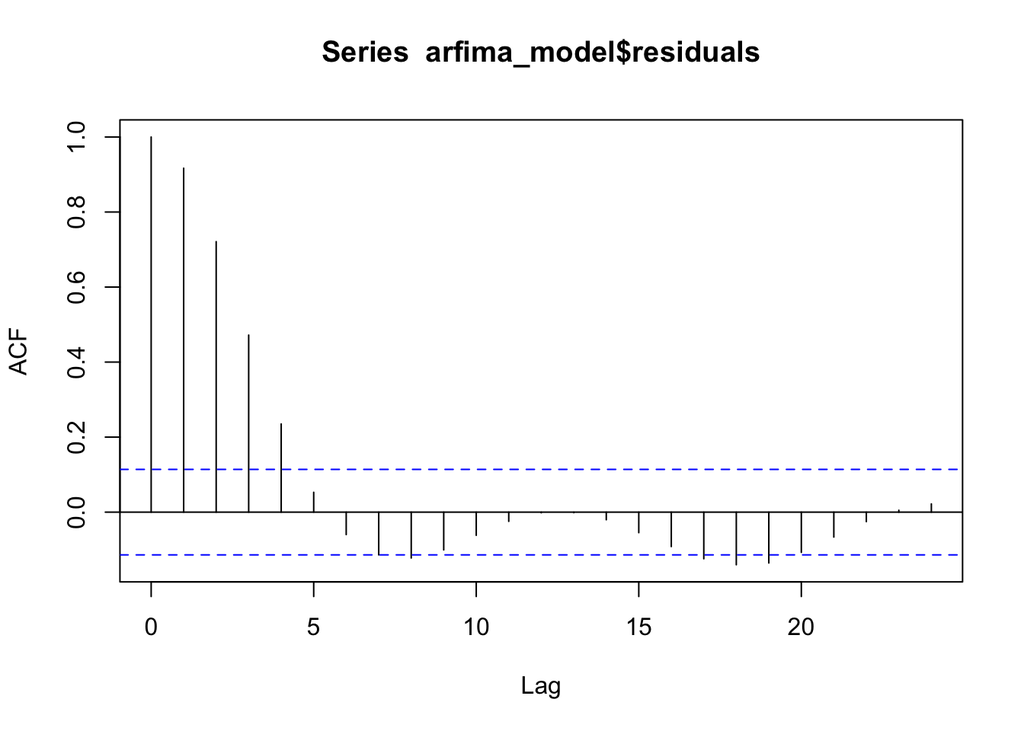

```r
acf(arfima_model$residuals)
```

Ans9 - Based on ACF plots and test results, the ARIMA(2,0,2) model gives the best result in terms of residuals being close to white noise.

## Task10.1

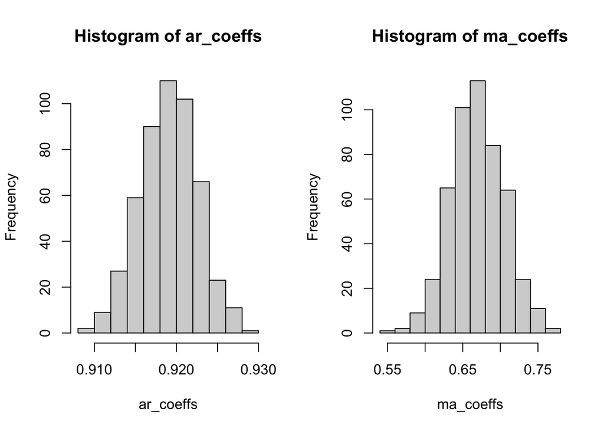

```r
library(lmtest)
library(forecast)

# Load the data (replace with your own data)

y <- residuals(lm(Gasfurn$dependent ~ Gasfurn$independent))

# Bootstrap residuals
set.seed(123)
nboot <- 500
boot_resids <- bld.mbb.bootstrap(y, nboot)
boot_resids<-as.matrix(boot_resids)
estimate_arima <- function(x) {
  x <- as.numeric(x)  # ensure input is numeric
  if (length(x) < 3) {
    return(c(ar=NA, ma=NA))  # return NA coefficients for short series
  }
  tryCatch({
    model <- Arima(x, order=c(1,0,1), include.mean=FALSE)
    return(c(ar=model$coef[1], ma=model$coef[2]))
  }, error = function(e) {
    return(c(ar=NA, ma=NA))
  })
}


ar_coeffs <- ma_coeffs <- rep(NA, nboot)
for (i in 1:nboot) {
  resids_i <- as.numeric(boot_resids[[i]])
  coeffs <- estimate_arima(resids_i)
  ar_coeffs[i] <- coeffs["ar.ar1"]
  ma_coeffs[i] <- coeffs["ma.ma1"]
}

# Plot the coefficient distributions
par(mfrow=c(1,2))
hist(ar_coeffs)
hist(ma_coeffs)
```

## Task10.2

```r
ar_ci <- quantile(ar_coeffs, c(0.025, 0.975))
cat("95% Confidence interval for AR coefficient:", ar_ci, "\n")
```

```
## 95% Confidence interval for AR coefficient: 0.9123613 0.9258276
```

```r
ma_ci <- quantile(ma_coeffs, c(0.025, 0.975))
cat("95% Confidence interval for MA coefficient:", ma_ci, "\n")
```

```
## 95% Confidence interval for MA coefficient: 0.6020296 0.7396875
```

Ans10.2 - 95% Confidence interval for AR coefficient: 0.91, 0.93 95% Confidence interval for MA coefficient: 0.60, 0.74